## Course: COMPUTATIONAL THINKING FOR GOVERNANCE ANALYTICS

### Prof. José Manuel Magallanes, PhD

- Visiting Professor of Computational Policy at Evans School of Public Policy and Governance, and eScience Institute Senior Data Science Fellow, University of Washington.
- Professor of Government and Political Methodology, Pontificia Universidad Católica del Perú.

# Basic Modeling in R

Collect the data about democracy that we prepared in Python:

```r
link='https://github.com/EvansDataScience/CTforGA_integrating/raw/main/allDataFull_OK.RDS'
# a RDS file from the web needs:
myFile=url(link)

# reading in data:
fromPy=readRDS(file = myFile)

# reset indexes to R format:
row.names(fromPy)=NULL
```

```r
idhLink="https://github.com/EvansDataScience/CTforGA_BasicModeling/raw/main/hdi2019.csv"
idhdata=read.csv(idhLink)
```

```r
demoidh=merge(fromPy,idhdata,by.x = "Country",by.y = "country")
```

Verifying data structure:

```r
str(demoidh,width = 70,strict.width='cut')
```

```
## 'data.frame':    164 obs. of  13 variables:
##  $ Country                     : chr  "Afghanistan" "Albania" "Alge"..
##  $ Regimetype                  : Ord.factor w/ 4 levels "Authoritar"..
##  $ Overallscore                : num  2.85 6.08 3.77 3.66 6.95 5.35 ..
##  $ Electoralprocessandpluralism: num  3.42 7 3.08 2.25 9.17 7.5 10 9..
##  $ Functioningofgovernment     : num  0.64 5.36 2.5 2.86 5.36 5 8.57..
##  $ Politicalparticipation      : num  3.89 4.44 4.44 5.56 6.67 6.11 ..
##  $ Politicalculture            : num  2.5 6.25 5 5 5.63 3.13 8.75 6...
##  $ Civilliberties              : num  3.82 7.35 3.82 2.65 7.94 5 9.7..
##  $ InternetccTLD               : chr  ".af" ".al" ".dz" ".ao" ...
##  $ iso2                        : chr  "AF" "AL" "DZ" "AO" ...
##  $ iso3                        : chr  "AFG" "ALB" "DZA" "AGO" ...
##  $ Region                      : chr  "Asia" "Europe" "Africa" "Afr"..
##  $ hdi                         : num  0.511 0.795 0.748 0.581 0.845 ..
```

# R for Regression

## Continuous outcome

Generally speaking, we use regression when we have a continuous outcome o dependent variable, and a set of independent variables of different type.

### * **EXPLANATORY APPROACH**

1. State hypotheses:

Prepare your hypotheses:

```r
# hypothesis 1: hdi increases as we have more civil liberties:
hypo1=formula(hdi~ Civilliberties)

# hypothesis 2: hdi increases as Civil liberties and Political participation advance:

hypo2=formula(hdi~ Civilliberties + Politicalparticipation)
```

2. Compute regression models:

```r
#
# results
gauss1=glm(hypo1,
           data = demoidh,
           family = 'gaussian')

gauss2=glm(hypo2,
           data = demoidh,
           family = 'gaussian')
```

3. See results:
- First Hypothesis

```r
summary(gauss1)
```

```
##
## Call:
## glm(formula = hypo1, family = "gaussian", data = demoidh)
##
## Deviance Residuals:
##      Min        1Q    Median        3Q       Max
## -0.29910  -0.08158   0.01656   0.08502   0.28045
##
## Coefficients:
##                Estimate Std. Error t value Pr(>|t|)
## (Intercept)    0.519309   0.022184   23.41   <2e-16 ***
## Civilliberties 0.036899   0.003648   10.12   <2e-16 ***
## ---
## Signif. codes:  0 '***' 0.001 '**' 0.01 '*' 0.05 '.' 0.1 ' ' 1
##
## (Dispersion parameter for gaussian family taken to be 0.01489487)
##
##     Null deviance: 3.937  on 163  degrees of freedom
## Residual deviance: 2.413  on 162  degrees of freedom
## AIC: -220.51
##
## Number of Fisher Scoring iterations: 2
```

- Second Hypothesis

```r
summary(gauss2)
```

```
##
## Call:
## glm(formula = hypo2, family = "gaussian", data = demoidh)
##
## Deviance Residuals:
##       Min         1Q     Median         3Q        Max
## -0.254629  -0.089074   0.009819   0.071388   0.316221
##
## Coefficients:
##                        Estimate Std. Error t value Pr(>|t|)
## (Intercept)            0.455915   0.027814  16.391  < 2e-16 ***
## Civilliberties         0.021656   0.005533   3.914 0.000134 ***
## Politicalparticipation 0.027242   0.007625   3.573 0.000466 ***
## ---
## Signif. codes:  0 '***' 0.001 '**' 0.01 '*' 0.05 '.' 0.1 ' ' 1
##
## (Dispersion parameter for gaussian family taken to be 0.01388646)
##
##     Null deviance: 3.9370  on 163  degrees of freedom
## Residual deviance: 2.2357  on 161  degrees of freedom
## AIC: -231.02
##
## Number of Fisher Scoring iterations: 2
```

4. Search for *better* model:

```r
anova(gauss1,gauss2,test="Chisq")
```

```
## Analysis of Deviance Table
##
## Model 1: hdi ~ Civilliberties
## Model 2: hdi ~ Civilliberties + Politicalparticipation
##   Resid. Df Resid. Dev Df Deviance  Pr(>Chi)
## 1       162     2.4130
## 2       161     2.2357  1  0.17725 0.0003533 ***
## ---
## Signif. codes:  0 '***' 0.001 '**' 0.01 '*' 0.05 '.' 0.1 ' ' 1
```

Model for the second hypothesis is chosen. You can get the RSquared if needed:

```r
library(rsq)
rsq(gauss2,adj=T)
```

```
## [1] 0.4250701
```

5. Verify the situation of chosen model:

5.1. Linearity between dependent variable and predictors is assumed, then these dots should follow a linear and horizontal trend:

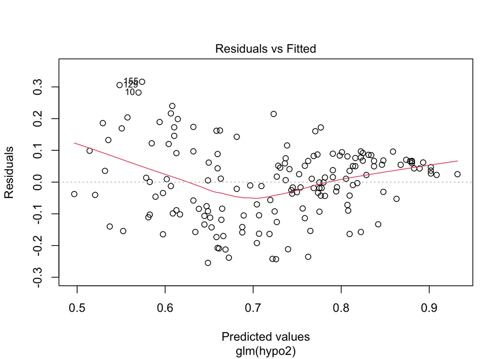

```r
plot(gauss2,1)
```

The linear relationship does not hold that well.

5.2. Normality of residuals is assumed:

Visual exploration:

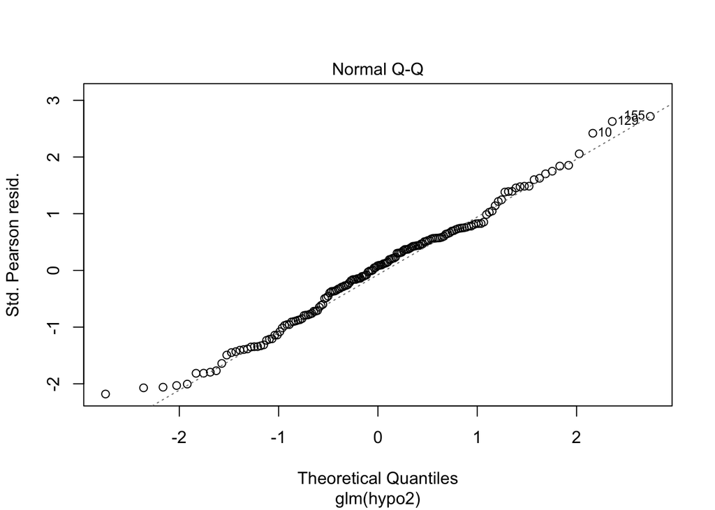

```r
plot(gauss2,2)
```

Mathematical exploration:

```r
# The data is normal if the p-value is above 0.05
shapiro.test(gauss2$residuals)
```

```
##
##  Shapiro-Wilk normality test
##
## data:  gauss2$residuals
## W = 0.9893, p-value = 0.2504
```

5.3. Homoscedasticity is assumed, so you need to check if residuals are spread equally along the ranges of predictors:

Visual exploration:

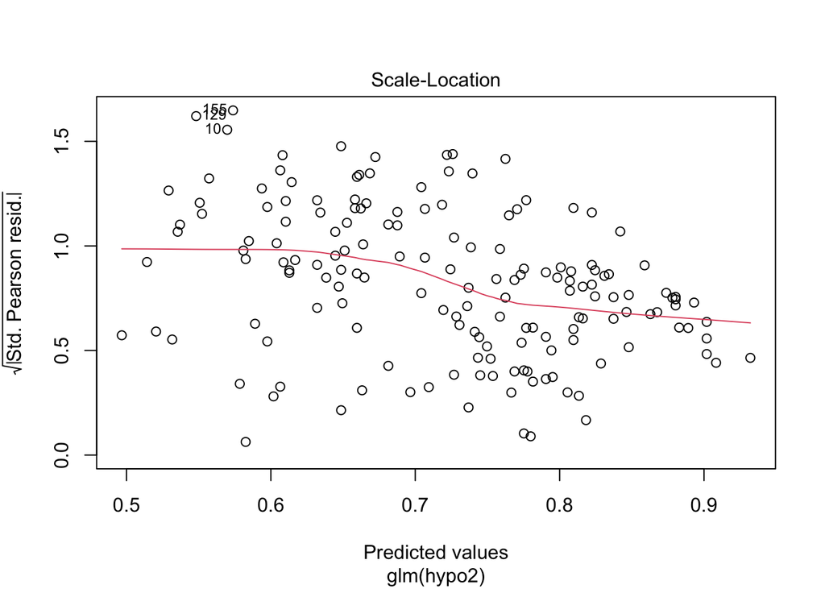

```r
plot(gauss2, 3)
```

Mathematical exploration:

```r
library(lmtest)
#pvalue<0.05 you cannot assume Homoscedasticity
bptest(gauss2)
```

```
##
##  studentized Breusch-Pagan test
##
## data:  gauss2
## BP = 28.048, df = 2, p-value = 8.117e-07
```

5.4. We assume that there is no colinearity, that is, that the predictors are not correlated.

```r
library(car)
vif(gauss2) # lower than 5 is desirable
```

```
##         Civilliberties Politicalparticipation
##               2.467331               2.467331
```

5.5. Analize the effect of atypical values. Determine if outliers (points that are far from the rest, but still in the trend) or high-leverage points (far from the trend but close to the rest) are influential:

Visual exploration:

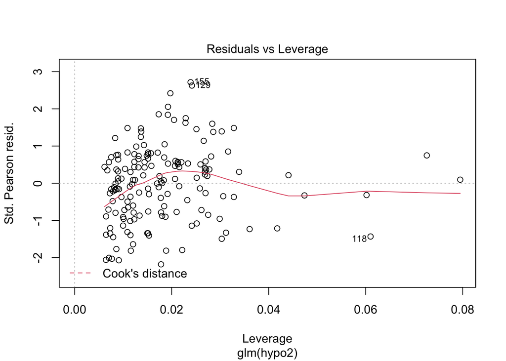

```r
plot(gauss2,5)
```

Querying:

```r
gaussInf=as.data.frame(influence.measures(gauss2)$is.inf)
gaussInf[gaussInf$cook.d,]
```

```
## [1] dfb.1_   dfb.Cvll dfb.Pltc dffit    cov.r    cook.d   hat
## <0 rows> (or 0-length row.names)
```

6. Finally, a nice summary plot of your work:

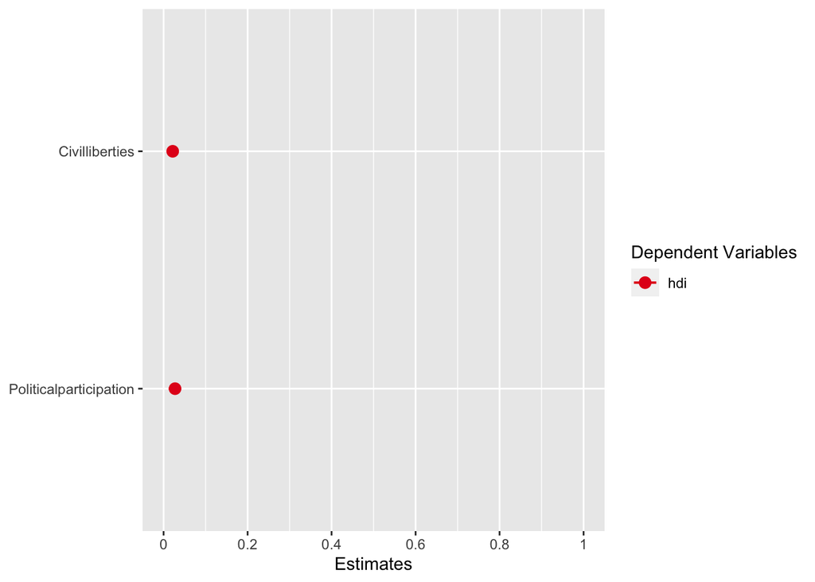

```r
library(sjPlot)
plot_models(gauss2,vline.color = "grey")
```

- **PREDICTIVE APPROACH**
1. Split the data set:

```r
library(caret)
set.seed(123)

selection = createDataPartition(demoidh$hdi,
                                p = 0.75,
                                list = FALSE)
#
trainGauss = demoidh[ selection, ]
#
testGauss  = demoidh[-selection, ]
```

2. Regress with train data

Let’s use cross validation, applying the regression to five samples from the training data set:

```r
ctrl = trainControl(method = 'cv',number = 5)

gauss2CV = train(hypo2,
                 data = trainGauss,
                 method = 'glm',
                 trControl = ctrl)

gauss2CV
```

```
## Generalized Linear Model
##
## 124 samples
##   2 predictor
##
## No pre-processing
## Resampling: Cross-Validated (5 fold)
## Summary of sample sizes: 100, 99, 99, 98, 100
## Resampling results:
##
##   RMSE       Rsquared   MAE
##   0.1162105  0.4741423  0.09141771
```

Just checking the Rsquared above tells us that it is not a good model for predicting.

3. Evaluate performance

```r
predictedVal<-predict(gauss2CV,testGauss)

postResample(obs = testGauss$hdi,
             pred=predictedVal)
```

```
##      RMSE  Rsquared       MAE
## 0.1215649 0.3318391 0.1035307
```

From the information above, you do noy a better prediction: the Rsquared from *postResample* is below 0.5.

## Binary outcome

In this situation you have binary dependent variable, which we do not currently have:

```r
demoidh$HDIdico=ifelse(demoidh$hdi>median(demoidh$hdi,
                                       na.rm = T),
                     1,0)
```

Now we have it.

### * **EXPLANATORY APPROACH**

1. State hypothesis:

Let’s use the same ones:

```r
hypoDico1=formula(HDIdico~ Civilliberties)
hypoDico2=formula(HDIdico~ Civilliberties + Politicalparticipation)
```

2. Reformat

```r
demoidh$HDIdico=factor(demoidh$HDIdico)
```

6. Compute regression models:

```r
Logi1=glm(hypoDico1,data = demoidh,
          family = "binomial")
Logi2=glm(hypoDico2,data = demoidh,
          family = "binomial")
```

7. See results:
- First Hypothesis:

```r
summary(Logi1)
```

```
##
## Call:
## glm(formula = hypoDico1, family = "binomial", data = demoidh)
##
## Deviance Residuals:
##      Min        1Q    Median        3Q       Max
## -1.83766  -0.90008   0.06632   0.78753   2.12472
##
## Coefficients:
##                Estimate Std. Error z value Pr(>|z|)
## (Intercept)    -2.72960    0.49248  -5.543 2.98e-08 ***
## Civilliberties  0.49400    0.08201   6.024 1.70e-09 ***
## ---
## Signif. codes:  0 '***' 0.001 '**' 0.01 '*' 0.05 '.' 0.1 ' ' 1
##
## (Dispersion parameter for binomial family taken to be 1)
##
##     Null deviance: 227.35  on 163  degrees of freedom
## Residual deviance: 177.79  on 162  degrees of freedom
## AIC: 181.79
##
## Number of Fisher Scoring iterations: 3
```

- Second Hypothesis:

```r
summary(Logi2)
```

```
##
## Call:
## glm(formula = hypoDico2, family = "binomial", data = demoidh)
##
## Deviance Residuals:
##      Min        1Q    Median        3Q       Max
## -1.81056  -0.84524   0.02125   0.81156   2.19181
##
## Coefficients:
##                        Estimate Std. Error z value Pr(>|z|)
## (Intercept)             -3.4235     0.6610  -5.179 2.23e-07 ***
## Civilliberties           0.3587     0.1102   3.253  0.00114 **
## Politicalparticipation   0.2654     0.1532   1.732  0.08325 .
## ---
## Signif. codes:  0 '***' 0.001 '**' 0.01 '*' 0.05 '.' 0.1 ' ' 1
##
## (Dispersion parameter for binomial family taken to be 1)
##
##     Null deviance: 227.35  on 163  degrees of freedom
## Residual deviance: 174.73  on 161  degrees of freedom
## AIC: 180.73
##
## Number of Fisher Scoring iterations: 4
```

8. Search for better model:

```r
lrtest(Logi1,Logi2)
```

```
## Likelihood ratio test
##
## Model 1: HDIdico ~ Civilliberties
## Model 2: HDIdico ~ Civilliberties + Politicalparticipation
##   #Df  LogLik Df Chisq Pr(>Chisq)
## 1   2 -88.897
## 2   3 -87.367  1 3.059    0.08029 .
## ---
## Signif. codes:  0 '***' 0.001 '**' 0.01 '*' 0.05 '.' 0.1 ' ' 1
```

You do not have much of an improvement in the second case, but I will keep it.

9. Verify the situation of chosen model

9.1. Linearity assumption (Box-Tidwell test)

```r
DataRegLogis=demoidh
DataRegLogis$civilTEST=demoidh$Civilliberties*log(demoidh$Civilliberties)
DataRegLogis$particTEST=demoidh$Politicalparticipation*log(demoidh$Politicalparticipation)

DicoTest=formula(HDIdico~ Civilliberties + Politicalparticipation + civilTEST + particTEST)

summary(glm(DicoTest,data=DataRegLogis,family = binomial))
```

```
##
## Call:
## glm(formula = DicoTest, family = binomial, data = DataRegLogis)
##
## Deviance Residuals:
##     Min       1Q   Median       3Q      Max
## -2.0022  -0.7799   0.1860   0.7716   1.9565
##
## Coefficients:
##                        Estimate Std. Error z value Pr(>|z|)
## (Intercept)              0.8601     2.1515   0.400   0.6893
## Civilliberties          -1.4970     0.8447  -1.772   0.0764 .
## Politicalparticipation  -0.4595     1.3426  -0.342   0.7322
## civilTEST                0.7194     0.3266   2.203   0.0276 *
## particTEST               0.2908     0.5131   0.567   0.5709
## ---
## Signif. codes:  0 '***' 0.001 '**' 0.01 '*' 0.05 '.' 0.1 ' ' 1
##
## (Dispersion parameter for binomial family taken to be 1)
##
##     Null deviance: 225.96  on 162  degrees of freedom
## Residual deviance: 167.28  on 158  degrees of freedom
##   (1 observation deleted due to missingness)
## AIC: 177.28
##
## Number of Fisher Scoring iterations: 5
```

9.2. We assume that there is no colinearity, that is, that the predictors are not correlated.

```r
vif(Logi2)
```

```
##         Civilliberties Politicalparticipation
##               1.760294               1.760294
```

9.3 Analize the effect of atypical values. Determine if outliers (points that are far from the rest, but still in the trend) or high-leverage points (far from the trend but close to the rest) are influential:

Visual exploration:

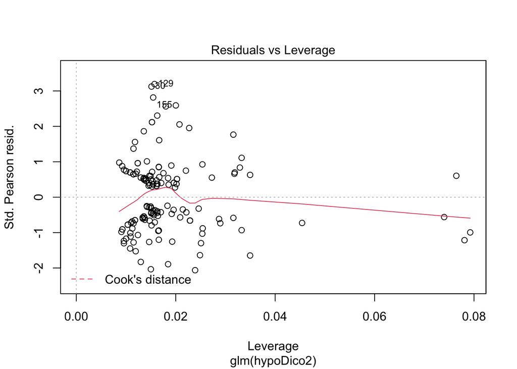

```r
plot(Logi2,5)
```

10. Finally, a nice summary plot of your work by computing the marginal effects:

```r
library(margins)
(modelChosen = margins(Logi2))
```

```
## Average marginal effects
```

```
## glm(formula = hypoDico2, family = "binomial", data = demoidh)
```

```
##  Civilliberties Politicalparticipation
##         0.06364                0.04708
```

```r
(margins=summary(modelChosen))
```

```
##                  factor    AME     SE      z      p   lower  upper
##          Civilliberties 0.0636 0.0172 3.7032 0.0002  0.0300 0.0973
##  Politicalparticipation 0.0471 0.0264 1.7847 0.0743 -0.0046 0.0988
```

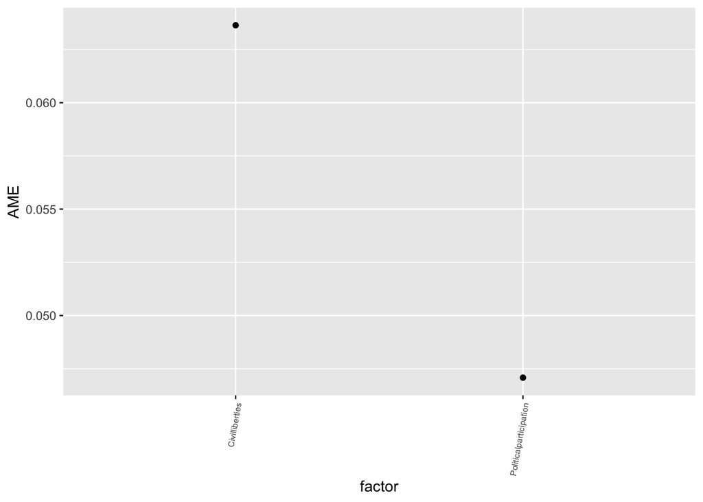

```r
base= ggplot(margins,aes(x=factor, y=AME)) + geom_point()
plot2 = base + theme(axis.text.x = element_text(angle = 80,
                                              size = 6,
                                              hjust = 1))
plot2
```

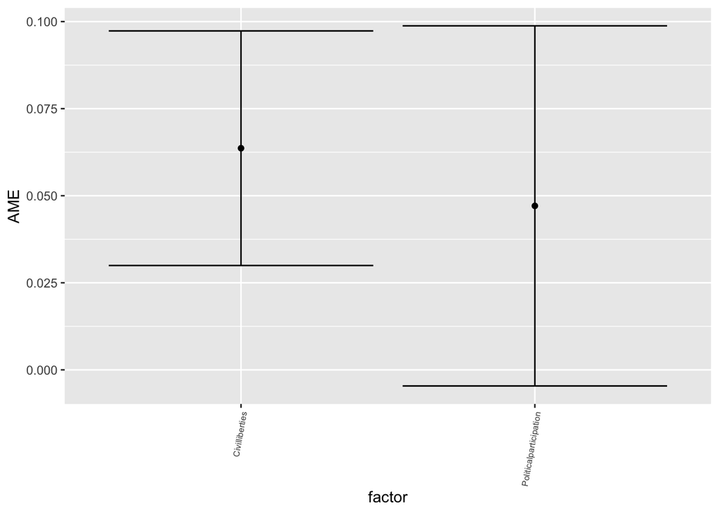

```r
plot2 +  geom_errorbar(aes(ymin=lower, ymax=upper))
```

### * **PREDICTIVE APPROACH**

1. Split the data set:

```r
set.seed(123)

selection = createDataPartition(demoidh$HDIdico,
                                p = 0.75,
                                list = FALSE)
trainLogi = demoidh[selection, ]
testLogi  = demoidh[-selection, ]
```

2. Regress with train data

Let’s use cross validation, applying the regression to five samples from the training data set:

```r
set.seed(123)
ctrl = trainControl(method = 'cv',number = 5)

Logis2CV = train(hypoDico2,
                 data = trainLogi,
                 method = 'glm',
                 family="binomial",
                 trControl = ctrl)
```

3. See results:

```r
Logis2CV
```

```
## Generalized Linear Model
##
## 124 samples
##   2 predictor
##   2 classes: '0', '1'
##
## No pre-processing
## Resampling: Cross-Validated (5 fold)
## Summary of sample sizes: 99, 100, 99, 99, 99
## Resampling results:
##
##   Accuracy   Kappa
##   0.7416667  0.4840711
```

3. Evaluate performance

3.1 Get predictions on test data

```r
predictions = predict(Logis2CV,
                      newdata=testLogi,
                      type='raw')
```

3.2 Assess performance

```r
confusionMatrix(data=predictions,
                reference=testLogi$HDIdico,
                positive = "1")
```

```
## Confusion Matrix and Statistics
##
##           Reference
## Prediction  0  1
##          0 15  3
##          1  5 17
##
##                Accuracy : 0.8
##                  95% CI : (0.6435, 0.9095)
##     No Information Rate : 0.5
##     P-Value [Acc > NIR] : 9.108e-05
##
##                   Kappa : 0.6
##
##  Mcnemar's Test P-Value : 0.7237
##
##             Sensitivity : 0.8500
##             Specificity : 0.7500
##          Pos Pred Value : 0.7727
##          Neg Pred Value : 0.8333
##              Prevalence : 0.5000
##          Detection Rate : 0.4250
##    Detection Prevalence : 0.5500
##       Balanced Accuracy : 0.8000
##
##        'Positive' Class : 1
##
```

Here is some help for you to interpret the [result](https://docs.google.com/presentation/d/e/2PACX-1vRyFvA5U2HXC3CGBeKEr209_KLjjdeo8FoKT6BxMsjLNOJwx7YDUmGEpDq1pzfGO7Zizuk5rogUNPgj/pub?start=false&loop=false&delayms=3000).